# Assay report

The assay was designed from an alignment of 621 sequences. The length of the alignment/region of interest was 2001 nucleotides. The report was generated 2020-07-21.

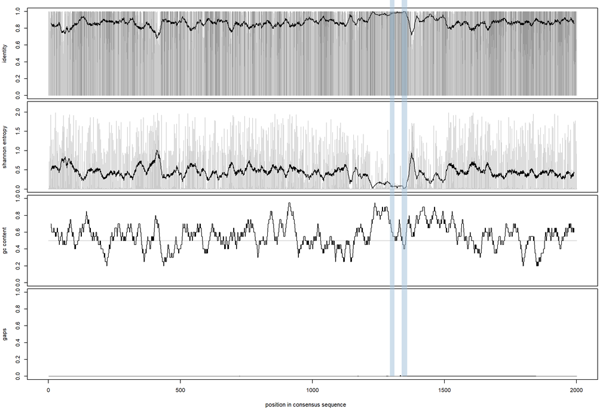

**Fig. 1.** Overview of the alignment/region of interest used for assay design, with the assay region indicated in blue. Identity: Proportion of the most frequently occurring base. Entropy: Shannon entropy, a measurement of variability. A value of zero indicate no variability and a high value indicate high variability. GC: GC-content. Gaps: Proportion of gaps. Vertical bars represent the value at each position. Black bars in the two uppermost figures represent values of 1 and 0, respectively (i.e. positions with complete conservation). The horizontal lines represent centered running averages.

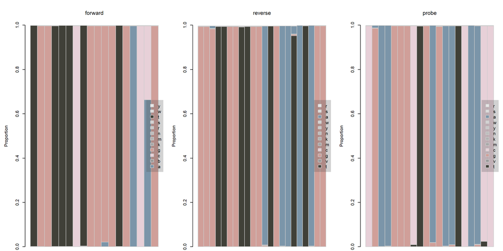

**Fig. 2.** Proportion of each nucleotide in the alignment at the oligo binding sites. Sequences are displayed from 5’- to 3’-end.  
**Table 1**. Assay info. Begin: Where the assay region starts (with regards to the alignment), End: Where the assay region ends. Tm difference, primers: Tm difference between the two primers (absolute value, in C). Tm difference, probe-primers: The Tm of the probe subtracted by the average Tm of the primer pair. Note that the Tm-differences are calculated from the majority oligos, and may thus be misleading for degenerate (IUPAC) oligos. Degeneracy; total number of oligo variants in the assay.

| Begin | End | Amplicon length | Tm difference, primers | Tm difference, probe-primers | Degeneracy | Perfect match (majority) | Perfect match (IUPAC) |
| --- | --- | --- | --- | --- | --- | --- | --- |
| 1294 | 1359 | 66 | 1.21 | 1.68 | 4 | 0.54 | 0.83 |

**Table 2.** Forward primer, summary.

| Begin | End | Length | Sequence (majority) | Sequence (IUPAC) | Degenerates | Degeneracy | GC-content (majority) | Tm (majority) | Perfect matches (majority) | Perfect matches (IUPAC) |
| --- | --- | --- | --- | --- | --- | --- | --- | --- | --- | --- |
| 1294 | 1311 | 18 | tggtttctggggtgacag | tggtttctggggtgacmg | 1 | 2 | 0.56 | 56.27 | 0.64 | 0.97 |

**Table 3.** Forward primer, all variants.

| Variant | GC-content | Tm |
| --- | --- | --- |
| tggtttctggggtgacag | 0.56 | 56.27 |
| tggtttctggggtgaccg | 0.61 | 59.09 |

**Table 4.** Forward primer, mean values.

| gc_content | 0.58 |
| --- | --- |
| tm | 57.68 |

**Table 5.** Reverse primer, summary.

| Begin | End | Length | Sequence (majority) | Sequence (IUPAC) | Degenerates | Degeneracy | GC-content (majority) | Tm (majority) | Perfect matches (majority) | Perfect matches (IUPAC) |
| --- | --- | --- | --- | --- | --- | --- | --- | --- | --- | --- |
| 1338 | 1359 | 22 | gggttggttggatgaatatagg | gggttggttggatgaatatagg | 0 | 1 | 0.45 | 55.06 | 0.93 | 0.93 |

**Table 6.** Reverse primer, all variants.

| Variant | GC-content | Tm |
| --- | --- | --- |
| gggttggttggatgaatatagg | 0.45 | 55.06 |

**Table 7.** Reverse primer, mean values.

| gc_content | 0.45 |
| --- | --- |
| tm | 55.06 |

**Table 8.** Probe, summary.

| Begin | End | Length | Sequence (majority) | Sequence (IUPAC) | Degenerates | Degeneracy | GC-content (majority) | Tm (majority) | Sense | Perfect matches (majority) | Perfect matches (IUPAC) |
| --- | --- | --- | --- | --- | --- | --- | --- | --- | --- | --- | --- |
| 1312 | 1331 | 20 | cgaagggctgagaatcaacc | cgaagggctgagaatcaacc | 0 | 1 | 0.55 | 57.95 | neg | 0.91 | 0.91 |

**Table 9.** Probe, all variants.

| Variant | GC-content | Tm |
| --- | --- | --- |
| cgaagggctgagaatcaacc | 0.55 | 57.95 |

**Table 10.** Probe, mean values.

| gc_content | 0.55 |
| --- | --- |
| tm | 57.95 |

#### Match report

**Table 11.** Perfectly matching sequences, majority oligos.

| AF082843.1 |
| --- |
| AY575858.1 |
| AY575859.1 |
| KT447526.1 |
| KT447528.1 |
| AB074918.2 |
| LF848974.1 |
| AB630970.1 |
| AB074920.3 |
| AF060669.1 |
| AX181882.1 |
| AX181883.1 |
| BD378126.1 |
| BD378127.1 |
| JN837481.1 |
| KJ507955.1 |
| HQ709170.1 |
| JC087002.1 |
| HW532736.1 |
| HQ389544.1 |
| JQ679013.1 |
| HQ389543.1 |
| JC087006.1 |
| HW532737.1 |
| JQ679014.1 |
| JN564006.1 |
| FJ426403.1 |
| AB591734.1 |
| MG833836.1 |
| KX574712.1 |
| KF303502.2 |

[output cut: 306 more lines]

**Table 12.** Mismatching sequences, majority oligos. TRUE = matching, FALSE = mismatching.

|  | majority_fwd | majority_rev | majority_pr |
| --- | --- | --- | --- |
| D11092.1 | FALSE | TRUE | TRUE |
| M80581.1 | FALSE | TRUE | TRUE |
| AF444002.1 | FALSE | TRUE | TRUE |
| AF444003.1 | FALSE | TRUE | TRUE |
| HI577563.1 | FALSE | TRUE | TRUE |
| L25595.1 | FALSE | TRUE | TRUE |
| L25547.1 | FALSE | TRUE | TRUE |
| L08816.1 | FALSE | TRUE | FALSE |
| NC_001434.1 | FALSE | TRUE | FALSE |
| M94177.1 | FALSE | TRUE | FALSE |
| JQ655734.1 | FALSE | TRUE | TRUE |
| D11093.1 | FALSE | TRUE | TRUE |
| X98292.1 | FALSE | FALSE | TRUE |
| JF443717.1 | FALSE | TRUE | TRUE |
| D10330.1 | FALSE | TRUE | TRUE |
| DD496417.1 | FALSE | TRUE | TRUE |
| M73218.1 | FALSE | TRUE | TRUE |
| AF185822.1 | FALSE | TRUE | TRUE |
| AF076239.3 | FALSE | TRUE | TRUE |
| AX211247.1 | FALSE | TRUE | TRUE |
| AX211244.1 | FALSE | TRUE | TRUE |
| AF459438.1 | FALSE | TRUE | TRUE |
| JF443720.1 | FALSE | TRUE | TRUE |
| AF051830.1 | FALSE | TRUE | TRUE |
| DQ459342.1 | FALSE | TRUE | TRUE |
| JF443718.1 | FALSE | TRUE | TRUE |
| JF443719.1 | FALSE | TRUE | TRUE |
| LC061267.1 | FALSE | TRUE | TRUE |
| AH006999.2 | FALSE | TRUE | FALSE |
| X99441.1 | FALSE | TRUE | TRUE |

[output cut: 254 more lines]

**Table 13** Perfectly matching sequences, IUPAC oligos.

| D11092.1 |
| --- |
| M80581.1 |
| AF444002.1 |
| AF444003.1 |
| HI577563.1 |
| L25595.1 |
| L25547.1 |
| JQ655734.1 |
| D11093.1 |
| JF443717.1 |
| D10330.1 |
| DD496417.1 |
| M73218.1 |
| AF185822.1 |
| AF076239.3 |
| AX211247.1 |
| AX211244.1 |
| AF459438.1 |
| JF443720.1 |
| AF051830.1 |
| DQ459342.1 |
| JF443718.1 |
| JF443719.1 |
| LC061267.1 |
| X99441.1 |
| MH504157.1 |
| FJ457024.1 |
| JF443721.1 |
| JF443722.1 |
| JF443725.1 |
| MH074880.1 |

[output cut: 487 more lines]

**Table 14.** Mismatching sequences, IUPAC oligos. TRUE = matching, FALSE = mismatching.

|  | iupac_fwd | iupac_rev | iupac_pr |
| --- | --- | --- | --- |
| L08816.1 | TRUE | TRUE | FALSE |
| NC_001434.1 | TRUE | TRUE | FALSE |
| M94177.1 | TRUE | TRUE | FALSE |
| X98292.1 | TRUE | FALSE | TRUE |
| AH006999.2 | TRUE | TRUE | FALSE |
| MH504163.1 | TRUE | FALSE | TRUE |
| AY575857.1 | TRUE | FALSE | FALSE |
| AF060668.1 | FALSE | TRUE | TRUE |
| AX181807.1 | FALSE | TRUE | TRUE |
| AX181808.1 | FALSE | TRUE | TRUE |
| BD378054.1 | FALSE | TRUE | TRUE |
| BD378055.1 | FALSE | TRUE | TRUE |
| AB481228.1 | TRUE | TRUE | FALSE |
| AB089824.1 | TRUE | TRUE | FALSE |
| FJ426404.1 | TRUE | TRUE | FALSE |
| KT727028.1 | TRUE | TRUE | FALSE |
| KX981911.1 | TRUE | TRUE | FALSE |
| MH450022.1 | TRUE | FALSE | FALSE |
| AB222183.1 | TRUE | TRUE | FALSE |
| AB425831.1 | TRUE | TRUE | FALSE |
| AB593690.1 | TRUE | TRUE | FALSE |
| MF444136.1 | TRUE | TRUE | FALSE |
| MH377723.1 | TRUE | TRUE | FALSE |
| MH377727.1 | TRUE | TRUE | FALSE |
| MH450021.1 | TRUE | TRUE | FALSE |
| KJ701409.1 | TRUE | TRUE | FALSE |
| MH377722.1 | TRUE | TRUE | FALSE |
| FJ998008.1 | TRUE | TRUE | FALSE |
| MH377721.1 | TRUE | TRUE | FALSE |
| KP294371.1 | TRUE | TRUE | FALSE |

[output cut: 73 more lines]